```python
import warnings
warnings.simplefilter(action='ignore', category=FutureWarning)
warnings.simplefilter(action='ignore', category=DeprecationWarning)

import numpy as np
import pandas as pd
import seaborn as sns
```

# 1. Indtroduction

nfl_elo.csv contains game-by-game Elo ratings (Elo is a closed system where every point gained by one team is a point lost by another) and forecasts back to 1920.

```python
allNFL = pd.read_csv("nfl_elo.csv")
allNFL.head()
```

|  | date | season | neutral | playoff | team1 | team2 | elo1_pre | elo2_pre | elo_prob1 | elo_prob2 | ... | qb2_game_value | qb1_value_post | qb2_value_post | qbelo1_post | qbelo2_post | score1 | score2 | quality | importance | total_rating |
| --- | --- | --- | --- | --- | --- | --- | --- | --- | --- | --- | --- | --- | --- | --- | --- | --- | --- | --- | --- | --- | --- |
| 0 | 1920-09-26 | 1920 | 0 | NaN | RII | STP | 1503.947 | 1300.000 | 0.824651 | 0.175349 | ... | NaN | NaN | NaN | NaN | NaN | 48 | 0 | NaN | NaN | NaN |
| 1 | 1920-10-03 | 1920 | 0 | NaN | AKR | WHE | 1503.420 | 1300.000 | 0.824212 | 0.175788 | ... | NaN | NaN | NaN | NaN | NaN | 43 | 0 | NaN | NaN | NaN |
| 2 | 1920-10-03 | 1920 | 0 | NaN | BFF | WBU | 1478.004 | 1300.000 | 0.802000 | 0.198000 | ... | NaN | NaN | NaN | NaN | NaN | 32 | 6 | NaN | NaN | NaN |
| 3 | 1920-10-03 | 1920 | 0 | NaN | DAY | COL | 1493.002 | 1504.908 | 0.575819 | 0.424181 | ... | NaN | NaN | NaN | NaN | NaN | 14 | 0 | NaN | NaN | NaN |
| 4 | 1920-10-03 | 1920 | 0 | NaN | RII | MUN | 1516.108 | 1478.004 | 0.644171 | 0.355829 | ... | NaN | NaN | NaN | NaN | NaN | 45 | 0 | NaN | NaN | NaN |

5 rows × 33 columns

# 2. Preprocessing

```python
from numpy import NaN


nfl = allNFL.loc[allNFL["date"] >= "2017-09-07"]
nfl  = nfl.drop("neutral",axis=1)
nfl = nfl.drop("importance",axis=1)
nfl = nfl.drop("total_rating",axis=1)
nfl = nfl.fillna("n")
#replaces the NaN's in the playoff column with n which represents a non-playoff game

cols = ["elo1_pre","elo2_pre","elo_prob1","elo_prob2","elo1_post","elo2_post",
        "qbelo1_pre","qbelo2_pre","qb1_value_pre","qb2_value_pre","qb1_adj","qb2_adj",
        "qbelo_prob1","qbelo_prob2","qb1_game_value","qb2_game_value","qb1_value_post",
        "qb2_value_post","qbelo1_post","qbelo2_post","score1","score2","quality"]
#outlier detection
def is_outlier(x):
    Q25, Q75 = x.quantile([.25,.75])
    I = Q75 - Q25
    return (x < Q25 - 1.5*I) |  (x > Q75 + 1.5*I)

outl = nfl[cols].apply(is_outlier)
for col in cols:
    out =  nfl.loc[outl[col],col]
    print( "outliers in " + col)
    if not out.empty:
        print(out)

nfl.head()
```

```
outliers in elo1_pre
15936    1227.490928
15956    1219.337610
17069    1217.456406
Name: elo1_pre, dtype: float64
outliers in elo2_pre
15926    1231.838645
15971    1210.773886
15982    1201.561463
17041    1233.393097
17053    1222.225724
Name: elo2_pre, dtype: float64
outliers in elo_prob1
outliers in elo_prob2
outliers in elo1_post
```

[output cut: 152 more lines]

|  | date | season | playoff | team1 | team2 | elo1_pre | elo2_pre | elo_prob1 | elo_prob2 | elo1_post | ... | qbelo_prob2 | qb1_game_value | qb2_game_value | qb1_value_post | qb2_value_post | qbelo1_post | qbelo2_post | score1 | score2 | quality |
| --- | --- | --- | --- | --- | --- | --- | --- | --- | --- | --- | --- | --- | --- | --- | --- | --- | --- | --- | --- | --- | --- |
| 15740 | 2017-09-07 | 2017 | n | NE | KC | 1687.395154 | 1613.148952 | 0.690309 | 0.309691 | 1646.529757 | ... | 0.253030 | 39.100603 | 400.020698 | 229.550400 | 195.440810 | 1626.616848 | 1605.309919 | 27 | 42 | 95.0 |
| 15741 | 2017-09-10 | 2017 | n | CLE | PIT | 1335.767660 | 1598.852911 | 0.242271 | 0.757729 | 1329.605337 | ... | 0.764130 | 52.193001 | 169.429875 | 86.018744 | 182.850392 | 1340.915881 | 1603.053780 | 18 | 21 | 27.0 |
| 15742 | 2017-09-10 | 2017 | n | CIN | BAL | 1515.969638 | 1491.099567 | 0.626524 | 0.373476 | 1476.195532 | ... | 0.412898 | -235.201505 | 43.763990 | 123.092565 | 151.492584 | 1479.743800 | 1548.464635 | 0 | 20 | 56.0 |
| 15743 | 2017-09-10 | 2017 | n | BUF | NYJ | 1484.127683 | 1451.565526 | 0.636826 | 0.363174 | 1500.142289 | ... | 0.289442 | 161.895534 | 90.819847 | 163.301767 | 127.907467 | 1464.768579 | 1348.394459 | 21 | 12 | 10.0 |
| 15744 | 2017-09-10 | 2017 | n | HOU | JAX | 1502.139008 | 1381.984201 | 0.743804 | 0.256196 | 1451.208768 | ... | 0.327975 | -115.102578 | 142.320362 | 27.442070 | 150.016385 | 1469.052384 | 1470.615187 | 7 | 29 | 28.0 |

5 rows × 30 columns

# 3. Summary Data Analysis

.

statistical summaries of every numerical column in the form of box plots and numerical summaries

```
elo1_pre
count    1639.000000
mean     1512.499466
std       100.225540
min      1217.456406
25%      1444.568312
50%      1513.175041
75%      1582.497828
max      1777.933310
Name: elo1_pre, dtype: float64
elo2_pre
count    1639.000000
mean     1507.805605
std        97.034370
min      1201.561463
25%      1442.571702
50%      1508.127681
75%      1579.908910
max      1761.858581
Name: elo2_pre, dtype: float64
elo_prob1
count    1639.000000
mean        0.586480
std         0.169136
min         0.123942
25%         0.467316
50%         0.603330
75%         0.710388
max         0.953944
Name: elo_prob1, dtype: float64
elo_prob2
count    1639.000000
mean        0.413520
std         0.169136
min         0.046056
25%         0.289612
50%         0.396670
75%         0.532684
max         0.876058
Name: elo_prob2, dtype: float64
```

[output cut: 175 more lines]

```
25%        16.000000
50%        22.000000
75%        29.000000
max        59.000000
Name: score2, dtype: float64
quality
count    1639.000000
mean       48.269067
std        29.395812
min         0.000000
25%        22.000000
50%        48.000000
75%        74.000000
max       100.000000
Name: quality, dtype: float64
```

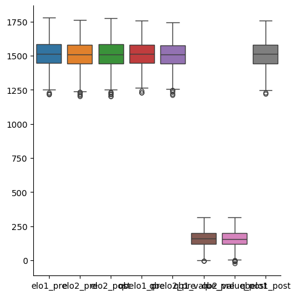

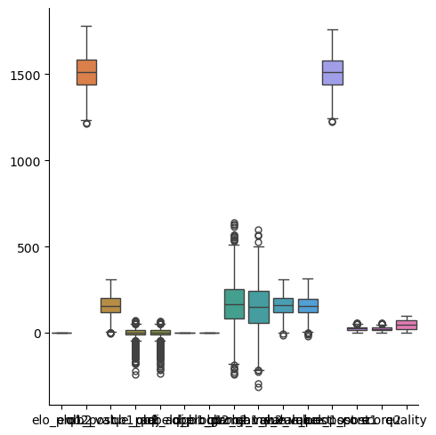

```python
col1 = ["elo1_pre","elo2_pre","elo2_post",
        "qbelo1_pre","qbelo2_pre","qb1_value_pre","qb2_value_post","qbelo1_post"]
col2 = ["elo_prob2","elo1_post","qb2_value_pre","qb1_adj","qb2_adj",
        "qbelo_prob1","qbelo_prob2","qb1_game_value","qb2_game_value","qb1_value_post",
        "qb2_value_post","qbelo1_post","score1","score2","quality"]

sns.catplot(data=nfl[col1],
     kind="box"
    )
sns.catplot(data=nfl[col2],
     kind="box"
    )

for col in cols:
    print(col)
    print(nfl[col].describe())
```

Correlation between pre and post elo scores for both teams and correlation between pre and post elo rating for both quaterbacks. i found that the team elo ratings and the quarterback elo ratings for both teams before and after the game were strongly linked.

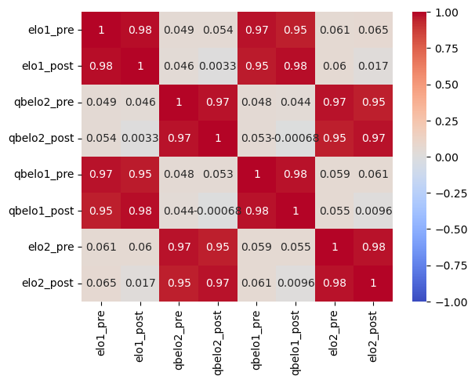

```python
from sklearn.model_selection import train_test_split
from sklearn.neighbors import KNeighborsClassifier
import seaborn as sns

colsC = nfl[["elo1_pre","elo1_post","qbelo2_pre","qbelo2_post","qbelo1_pre","qbelo1_post","elo2_pre","elo2_post"]]
C = colsC.corr()
sns.heatmap(C, annot=True,cmap = 'coolwarm',vmin=-1,vmax = 1)
```

# 4. Discussion

Questions :-

1. Can the historical Elo ratings of NFL teams, combined with quarterback performance metrics(such qb elo ratings pre,during and post game) and game context (such as season, playoff status, and venue), predict whether a game will result in an upset (i.e., the team with the lower Elo rating wins)
2. Can the combined Elo ratings of NFL teams before a game, along with quarterback performance metrics and game context (such as season, playoff status, and neutral venue), predict the total points scored in that game?